# Chainer でMINIST

[Qiita](http://qiita.com/kenmatsu4/items/7b8d24d4c5144a686412)

まず最初に必要なライブラリ群のインポートです。

```python
%matplotlib inline
import matplotlib.pyplot as plt
import numpy as np
from sklearn.datasets import fetch_mldata
from chainer import cuda, Variable, FunctionSet, optimizers
import chainer.functions  as F
import sys

plt.style.use('ggplot')
```

次に各種パラメーターの定義・設定を行います。

```python
# 確率的勾配降下法で学習させる際の１回分のバッチサイズ
batchsize = 100

# 学習の繰り返し回数
n_epoch   = 20

# 中間層の数
n_units   = 1000
```

Scikit LearnをつかってMNISTの手書き数字データをダウンロードします。

```python
# MNISTの手書き数字データのダウンロード
# #HOME/scikit_learn_data/mldata/mnist-original.mat にキャッシュされる
print 'fetch MNIST dataset'
mnist = fetch_mldata('MNIST original', )
print 'end > fetch MNIST dataset'
# mnist.data : 70,000件の784次元ベクトルデータ
mnist.data   = mnist.data.astype(np.float32)
mnist.data  /= 255     # 0-1のデータに変換
print("mnist.data.shape %r"%(mnist.data.shape,))

# mnist.target : 正解データ（教師データ）
mnist.target = mnist.target.astype(np.int32)
print("mnist.target.shape %r"%(mnist.target.shape,))
print(mnist.target[0:70000:1000])
```

```
fetch MNIST dataset
end > fetch MNIST dataset
mnist.data.shape (70000, 784)
mnist.target.shape (70000,)
[0 0 0 0 0 0 1 1 1 1 1 1 1 2 2 2 2 2 2 3 3 3 3 3 3 4 4 4 4 4 4 5 5 5 5 5 5
 6 6 6 6 6 7 7 7 7 7 7 7 8 8 8 8 8 8 9 9 9 9 9 0 1 1 2 3 4 5 7 7 9]
```

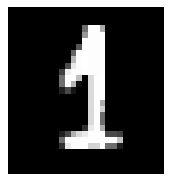

```python
def draw_digit(data):
    size = 28
    plt.figure(figsize=(2.5,3))
    X,Y = np.meshgrid(range(size), range(size))
    Z = data.reshape(size, size) # convert from vector to 28x28 matrix
    Z = Z[::-1,:] #frip vertical
    plt.xlim(0,27)
    plt.ylim(0,27)
    plt.pcolor(X, Y, Z)
    plt.gray()
    plt.tick_params(labelbottom="off")
    plt.tick_params(labelleft="off")

    plt.show()

import random
I =random.randint(0,70000)
draw_digit(mnist.data[I])
```

データセットを学習用データ(train), 検証用データ(test)に分割します。

```python
# 学習用データをN個, 検証用データを残りの個数と設定
N = 60000 # 学習用データ(traindata)の個数
x_train, x_test = np.split(mnist.data, [N])
y_train, y_test = np.split(mnist.target, [N])
N_test = y_test.size
```

```python
print("Training Data X: %r, Test Data X:%r" % (x_train.shape, x_test.shape))
print("Training Data Y: %r, Test Data Y:%r" % (y_train.shape, y_test.shape))
print("Test Data Size: %r" %(N_test,))
```

```
Training Data X: (60000, 784), Test Data X:(10000, 784)
Training Data Y: (60000,), Test Data Y:(10000,)
Test Data Size: 10000
```

## モデルの定義

ここからchainerのクラスや関数を使います

```python
# Prepare multi-layer perceptron model
# 入力 784次元, 出力10次元
# n_units:中間層のノード数
model = FunctionSet(l1=F.Linear(784, n_units),
                    l2=F.Linear(n_units, n_units),
                    l3=F.Linear(n_units, 10))
```

```python
# Neural net architecture
def forward(x_data, y_data, train=True):
    x, t = Variable(x_data), Variable(y_data)
    h1 = F.dropout(F.relu(model.l1(x)), train=train)
    h2 = F.dropout(F.relu(model.l2(h1)), train=train)
    y = model.l3(h2)
    # 多クラス分類なので誤差関数としてソフトマックス関数の，
    # 交差エントロピー関数を用いて，誤差を導出
    err = F.softmax_cross_entropy(y, t), F.accuracy(y, t)
    return err
```

説明 活性化関数にはシグモイド関数ではなく，F.relu()関数が使われている． F.relu(), 正規化(整流化)線形関数(Rectified Linear Unit function)

$ f(x) = max(0,x)$

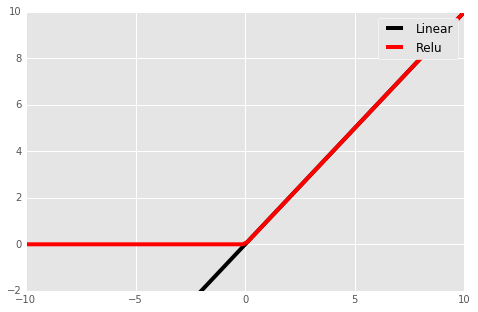

```python
def plot_relu_function():
    """Plot relu function (Rectified Linear Unit function)
    $ f(x) = max(0,x)$
    """
    x_data = np.linspace(-10, 10, 100, dtype=np.float32)
    x = Variable(x_data)
    y = F.relu(x)
    plt.figure(figsize=(7,5))
    plt.ylim(-2,10)
    plt.plot(x.data, x.data, c="k", label="Linear")
    plt.plot(x.data, y.data, c="r", label="Relu")
    plt.legend()
    plt.show()
plot_relu_function()
```

ついでにシグモイド関数もプロットしておく

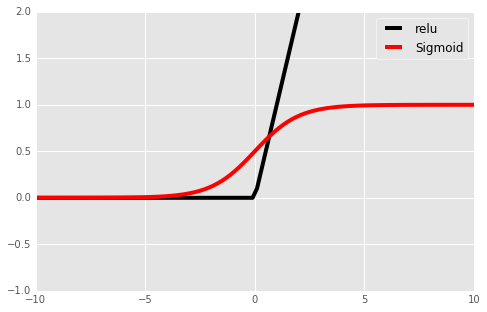

```python
def plot_sigmoid_function():
    """Plot Sigmoid function (Rectified Linear Unit function)
    $ f(x) = $
    """
    x_data = np.linspace(-10, 10, 100, dtype=np.float32)
    x = Variable(x_data)
    y = F.sigmoid(x)

    plt.figure(figsize=(7,5))
    plt.ylim(-1,2)
    plt.plot(x.data, F.relu(x).data, c="k", label="relu")
    plt.plot(x.data, y.data, c="r", label="Sigmoid")
    plt.legend()
    plt.show()

plot_sigmoid_function()
```

次に、このrelu()関数の出力を入力としてF.dropout()関数が使われています。

`F.dropout(F.relu(model.l1(x)), train=train)`  
このドロップアウト関数F.dropout()はDropout: A Simple Way to Prevent Neural Networks from Overfittingという論文で提唱されている手法で、ランダムに中間層をドロップ（ないものとする）し、そうすると過学習を防ぐことができるそうです。

```python
# dropout(x, ratio=0.5, train=True) テスト
# x: 入力値
# ratio: 0を出力する確率
# train: Falseの場合はxをそのまま返却
# return: ratioの確率で0を, 1-ratioの確率で x*(1/(1-raio))の値を返す
def dropout_test(n=50):
    v_sum = 0
    for i in range(n):
        x_data = np.array([1,2,3,4,5,6], dtype=np.float32)
        x = Variable(x_data)
        drout = F.dropout(x, ratio=0.6, train=True)

        for j in range(6):
            # sys.stdout.write( str(drout.data[j]) + ', ' )
            pass
        # print("")
        v_sum += drout.data
    sys.stdout.write( str((v_sum/float(n))))
    print("v_sumの値がx_dataと大体一致する")
dropout_test(10)
dropout_test(20)
dropout_test(30)
dropout_test(40)
```

```
[ 1.25  1.5   2.25  5.    5.    7.5 ]v_sumの値がx_dataと大体一致する
[ 1.125  2.5    4.5    3.     5.     6.75 ]v_sumの値がx_dataと大体一致する
[ 1.41666663  1.83333337  2.25        5.33333349  5.          5.5       ]v_sumの値がx_dataと大体一致する
[ 1.125   2.625   3.5625  5.25    5.3125  7.125 ]v_sumの値がx_dataと大体一致する
```

ソフトマックス関数 $$ y_k = z_k = f_k(u) = \frac{exp(u_k)}{\sum_{j}^{K} exp(u_j)} $$

また、F.accuracy(y, t)は出力と、教師データを照合して正答率を返しています。

### 3.3 Optimizerの設定

さて、モデルが決まったので訓練に移ります。 ここでは最適化手法としてAdamが使われています。

```python
# setup optimizer
optimizer = optimizers.Adam()
optimizer.setup(model.collect_parameters())
```

## 訓練の実施と結果

```python
train_loss = []
train_acc  = []
test_loss = []
test_acc  = []

l1_W = []
l2_W = []
l3_W = []

sys.stdout.write("Start Traning... \n")
sys.stdout.flush()


# Learning loop
for epoch in xrange(1, n_epoch+1):
    sys.stdout.write('epoch : %r \n'% epoch)
    sys.stdout.flush()

    # training
    # N個の順番をランダムに並び替える
    perm = np.random.permutation(N)
    sum_accuracy = 0
    sum_loss = 0

    # 0〜Nまでのデータをバッチサイズごとに使って学習
    for i in xrange(0, N, batchsize):
        x_batch = x_train[perm[i:i+batchsize]]
        y_batch = y_train[perm[i:i+batchsize]]

        # 勾配を初期化
        optimizer.zero_grads()
        # 順伝播させて誤差と精度を算出
        loss, acc = forward(x_batch, y_batch)
        # 誤差逆伝播で勾配を計算
        loss.backward()
        optimizer.update()

        train_loss.append(loss.data)
        train_acc.append(acc.data)
        sum_loss     += float(cuda.to_cpu(loss.data)) * batchsize
        sum_accuracy += float(cuda.to_cpu(acc.data)) * batchsize

    # 訓練データの誤差と、正解精度を表示
    print 'train mean loss={}, accuracy={}'.format(sum_loss / N, sum_accuracy / N)

    # evaluation
    # テストデータで誤差と、正解精度を算出し汎化性能を確認
    sum_accuracy = 0
    sum_loss     = 0
    for i in xrange(0, N_test, batchsize):
        x_batch = x_test[i:i+batchsize]
        y_batch = y_test[i:i+batchsize]

        # 順伝播させて誤差と精度を算出
        loss, acc = forward(x_batch, y_batch, train=False)

        test_loss.append(loss.data)
        test_acc.append(acc.data)
        sum_loss     += float(cuda.to_cpu(loss.data)) * batchsize
        sum_accuracy += float(cuda.to_cpu(acc.data)) * batchsize

    # テストデータでの誤差と、正解精度を表示
    print 'test  mean loss={}, accuracy={}'.format(sum_loss / N_test, sum_accuracy / N_test)

    # 学習したパラメーターを保存
    l1_W.append(model.l1.W)
    l2_W.append(model.l2.W)
    l3_W.append(model.l3.W)


print("Finish! Traning")
```

```
Start Traning...
epoch : 1
train mean loss=0.279751645743, accuracy=0.914216667619
test  mean loss=0.113104717449, accuracy=0.96430000484
epoch : 2
train mean loss=0.133636832619, accuracy=0.959916671614
test  mean loss=0.0949923452197, accuracy=0.970400005579
epoch : 3
train mean loss=0.111125651854, accuracy=0.965133337875
test  mean loss=0.0817618886273, accuracy=0.974700004458
epoch : 4
train mean loss=0.0937614082335, accuracy=0.971216674149
test  mean loss=0.0676713557763, accuracy=0.980100006461
epoch : 5
train mean loss=0.0843870923513, accuracy=0.973950009545
test  mean loss=0.0701202754574, accuracy=0.979100003839
epoch : 6
train mean loss=0.0751809157862, accuracy=0.977150010169
test  mean loss=0.0625997391609, accuracy=0.9812000072
epoch : 7
train mean loss=0.0732269460522, accuracy=0.976783342858
test  mean loss=0.0688666373772, accuracy=0.980200006366
epoch : 8
train mean loss=0.0656094058751, accuracy=0.979583343367
test  mean loss=0.0673648138038, accuracy=0.981300007701
epoch : 9
train mean loss=0.0649826198968, accuracy=0.979700011114
test  mean loss=0.0558723569509, accuracy=0.983900008798
epoch : 10
train mean loss=0.0582052912354, accuracy=0.981083343824
test  mean loss=0.0615832579025, accuracy=0.983300005198
epoch : 11
train mean loss=0.0593508580527, accuracy=0.98158334434
test  mean loss=0.057255026448, accuracy=0.985400007963
epoch : 12
train mean loss=0.0545044393571, accuracy=0.982800010145
test  mean loss=0.0689075936019, accuracy=0.981400003433
epoch : 13
train mean loss=0.0548943290812, accuracy=0.982633342544
test  mean loss=0.0622520331638, accuracy=0.983000005484
epoch : 14
train mean loss=0.0527798036635, accuracy=0.98370001177
test  mean loss=0.0632550492662, accuracy=0.983200005889
epoch : 15
train mean loss=0.0487258864515, accuracy=0.985566677153
test  mean loss=0.0681872219385, accuracy=0.983200006485
epoch : 16
train mean loss=0.048093864517, accuracy=0.984750010173
test  mean loss=0.0676494009346, accuracy=0.983200005889
epoch : 17
train mean loss=0.04779818262, accuracy=0.985516677697
test  mean loss=0.0636712313455, accuracy=0.983900008202
epoch : 18
train mean loss=0.0513659016651, accuracy=0.985333343248
test  mean loss=0.0661876722733, accuracy=0.984800005555
epoch : 19
train mean loss=0.0419041261177, accuracy=0.987050009271
test  mean loss=0.0618600813491, accuracy=0.985100006461
epoch : 20
train mean loss=0.0448144119402, accuracy=0.98650001049
test  mean loss=0.0697095882295, accuracy=0.981900003552
Finish! Traning
```

```
[]
```

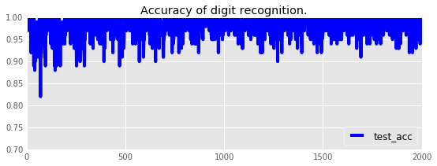

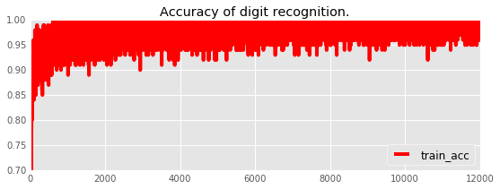

```python
# 精度のグラフ描画
plt.figure(figsize=(8,3))
plt.plot(range(len(test_acc)), test_acc, c='b')
plt.legend(["test_acc"],loc=4)
plt.title("Accuracy of digit recognition.")
plt.ylim(0.7,1)
plt.plot()
# 精度のグラフ描画
plt.figure(figsize=(8,3))
plt.plot(range(len(train_acc)), train_acc, c='r')
plt.legend(["train_acc"],loc=4)
plt.title("Accuracy of digit recognition.")
plt.ylim(0.7,1)
plt.plot()
```

```
[]
```

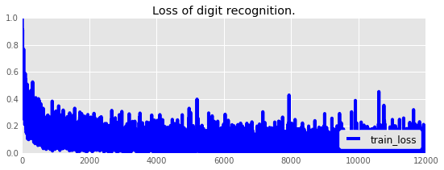

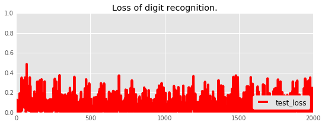

```python
# 誤差のグラフ描画
plt.figure(figsize=(8,3))
plt.plot(range(len(train_loss)), train_loss, c='b')
plt.legend(["train_loss"],loc=4)
plt.title("Loss of digit recognition.")
plt.ylim(0.0, 1)
plt.plot()
# 誤差のグラフ描画
plt.figure(figsize=(8,3))
plt.plot(range(len(test_loss)), test_loss, c='r')
plt.legend(["test_loss"],loc=4)
plt.title("Loss of digit recognition.")
plt.ylim(0.0,1)
plt.plot()
```

### 答え合わせ

```python
plt.style.use('fivethirtyeight')
def draw_digit3(data, n , ans, recog):
    size = 28
    plt.subplot(10,10,n)
    Z = data.reshape(size,size)
    Z = Z[::-1, :]
    plt.xlim(0,27)
    plt.ylim(0,27)
    plt.pcolor(Z)
    plt.title("ans=%d, recog=%d"%(ans, recog), size=8)
    plt.gray()
    plt.tick_params(labelbottom="off")
    plt.tick_params(labelleft="off")
plt.figure(figsize=(15,15))


cnt = 0
# for idx in np.random.permutation(N)[:1000]:
for idx in range(N):
    if mod(idx , 1000):
        pass

    xxx = x_train[idx].astype(np.float32)
    h1 = F.dropout(F.relu(model.l1(Variable(xxx.reshape(1,784)))), train=False)
    h2 = F.dropout(F.relu(model.l2(h1)), train=False)
    y = model.l3(h2)

    # 間違えだけ表示
    if y_train[idx] != np.argmax(y.data):
        cnt += 1
        draw_digit3(x_train[idx], cnt, y_train[idx], np.argmax(y.data))
plt.show()
print("Fin")
```

[output not shown]

## 第一層パラメータWの可視化

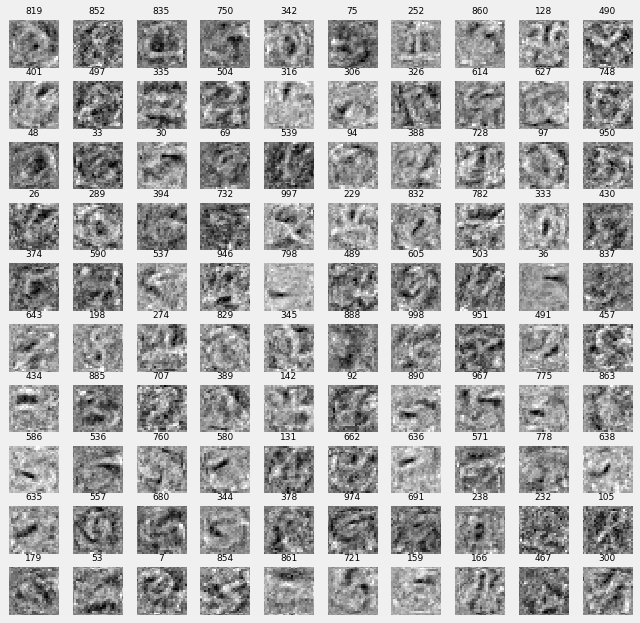

```
Fin
```

```python
def draw_digit2(data, n, i):
    size = 28
    plt.subplot(10, 10, n)
    Z = data.data.reshape(size,size)   # convert from vector to 28x28 matrix
    Z = Z[::-1,:]             # flip vertical
    plt.xlim(0,27)
    plt.ylim(0,27)
    plt.pcolor(Z)
    plt.title("%d"%i, size=9)
    plt.gray()
    plt.tick_params(labelbottom="off")
    plt.tick_params(labelleft="off")

plt.figure(figsize=(10,10))
cnt = 1
for i in np.random.permutation(1000)[:100]:
    draw_digit2(l1_W[len(l1_W)-1][i], cnt, i)
    cnt += 1

plt.show()
print("Fin")
```

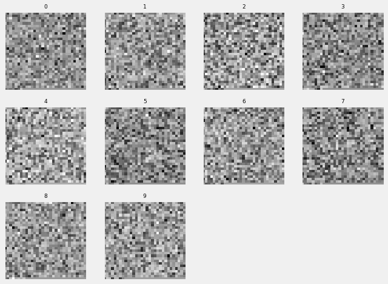

```python
# レイヤー3
def draw_digit2(data, n, i):
    data = data.data
    size = 32
    plt.subplot(4, 4, n)
    data = np.r_[data,np.zeros(24)]
    Z = data.reshape(size,size)   # convert from vector to 28x28 matrix
    Z = Z[::-1,:]             # flip vertical
    plt.xlim(0,size-1)
    plt.ylim(0,size-1)
    plt.pcolor(Z)
    plt.title("%d"%i, size=9)
    plt.gray()
    plt.tick_params(labelbottom="off")
    plt.tick_params(labelleft="off")

plt.figure(figsize=(10,10))
cnt = 1
for i in range(10):
    draw_digit2(l3_W[len(l3_W)-1][i], cnt, i)
    cnt += 1

plt.show()
```

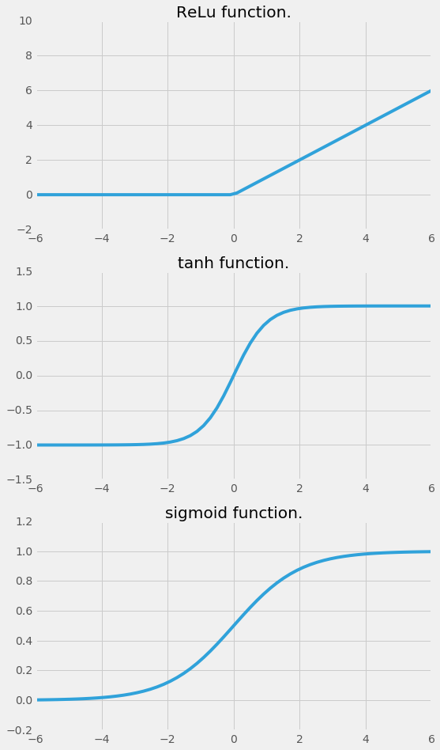

```python
# 活性化関数テスト
x_data = np.linspace(-10, 10, 100, dtype=np.float32)
x = Variable(x_data)

y = F.relu(x)
plt.figure(figsize=(8,15))
plt.subplot(311)
plt.title("ReLu function.")
plt.ylim(-2,10)
plt.xlim(-6,6)
plt.plot(x.data, y.data)

y = F.tanh(x)
plt.subplot(312)
plt.title("tanh function.")
plt.ylim(-1.5,1.5)
plt.xlim(-6,6)
plt.plot(x.data, y.data)

y = F.sigmoid(x)
plt.subplot(313)
plt.title("sigmoid function.")
plt.ylim(-.2,1.2)
plt.xlim(-6,6)
plt.plot(x.data, y.data)
plt.show()
```